# Exploratory Data Analytics on Netflix Data

[figure not shown]

# 1. Data Description

- 1.1 Introduction
- 1.2 Data Source & dataset

# 2.Load the packages & dataset

# 3.Data Exploration

- 3.1 Understanding the Dataset(Basic information about dataset)
- 3.2 Data Preperation(Data Cleaning)
- 3.3 Preprocessing

# 4.EDA Questions

- 4.1 What different types of show or movie are uploaded on Netflix?
- 4.2 Most watched shows on the Netflix?
- 4.3 Distribution of Ratings?
- 4.4 Which has the highest rating Tv show or Movies?
- 4.5 Finding the best Month for releasing content?
- 4.6 movies made on year basis?
- 4.7 Show only the title of all TV shows that were released in India only.
- 4.8 Show top 10 director, who gave the highest number of TV shows & Movies to Netflix?

# 5.Conclusions

## 1.Data Description

This Netflix Dataset has information about the TV shows and Movies available on Netflix from the year 2008 to 2021. Netflix is an application that keeps growing exponentially whole around the world and it is the most famous streaming platform.

## This dataset collected from Netflix of different TV shows and Movies from the year 2008 to 2021.

- **show_id**: Gives the information about show id.
- **type**: Gives information about 2 different unique values one is TV Show and another is Movie.
- **title**: Gives information about the title of Movie or TV Show.
- **director**: Gives information about the director who directed the Movie or TV Show.
- **cast**: Gives information about the cast who plays role in Movie or TV Show.
- **country**: Gives information about the Name of country.
- **date_added**: Gives information about the tv shows or movie released.
- **release_year**: Gives information about the year when Movie or TV Show was released.
- **rating**: Gives information about the Movie or TV Show are in which category (eg like the movies are only for students, or adults, etc).
- **duration**: Gives information about the duration of Movie or TV Show.
- **listed_in**: Gives information about the genre of Movie or TV Show.
- **description**: Gives information about the description of Movie or TV Show.

## 1.1 Introduction

This Exploratory Data Analysis is to practice Python skills learned till now on a structured data set including loading, inspecting, wrangling, exploring, and drawing conclusions from data. The notebook has observations with each step in order to explain thoroughly how to approach the data set. Based on the observation some questions also are answered in the notebook for the reference though not all of them are explored in the analysis.

## 1.2 Data source and data set

- Dataset Link: (https://drive.google.com/file/d/1dMALci6j_FQQg8idtfORQi2UXZ_pnTb6/view?usp=sharing)

# 2.Load the packages & dataset

## Import Libraries & Modules

```python
import numpy as np                 # for numerical computing
import pandas as pd                # for dataframe and manipulation
import seaborn as sns              #for graphs and data visualization
from matplotlib import pyplot as plt
sns.set()
%matplotlib inline
```

## Load the dataset

```python
netflix = pd.read_csv("C:/Users/Rishabh chaudhary/OneDrive/Desktop/New folder/netflix_titles_2021.csv")
```

# 3.Data Exploration

### 3.1 Understanding the Dataset(Basic information about dataset)

```python
netflix.head()  #for showing top 5 rows
```

|  | show_id | type | title | director | cast | country | date_added | release_year | rating | duration | listed_in | description |
| --- | --- | --- | --- | --- | --- | --- | --- | --- | --- | --- | --- | --- |
| 0 | s1 | Movie | Dick Johnson Is Dead | Kirsten Johnson | NaN | United States | September 25, 2021 | 2020 | PG-13 | 90 min | Documentaries | As her father nears the end of his life, filmm... |
| 1 | s2 | TV Show | Blood & Water | NaN | Ama Qamata, Khosi Ngema, Gail Mabalane, Thaban... | South Africa | September 24, 2021 | 2021 | TV-MA | 2 Seasons | International TV Shows, TV Dramas, TV Mysteries | After crossing paths at a party, a Cape Town t... |
| 2 | s3 | TV Show | Ganglands | Julien Leclercq | Sami Bouajila, Tracy Gotoas, Samuel Jouy, Nabi... | NaN | September 24, 2021 | 2021 | TV-MA | 1 Season | Crime TV Shows, International TV Shows, TV Act... | To protect his family from a powerful drug lor... |
| 3 | s4 | TV Show | Jailbirds New Orleans | NaN | NaN | NaN | September 24, 2021 | 2021 | TV-MA | 1 Season | Docuseries, Reality TV | Feuds, flirtations and toilet talk go down amo... |
| 4 | s5 | TV Show | Kota Factory | NaN | Mayur More, Jitendra Kumar, Ranjan Raj, Alam K... | India | September 24, 2021 | 2021 | TV-MA | 2 Seasons | International TV Shows, Romantic TV Shows, TV ... | In a city of coaching centers known to train I... |

```python
netflix.tail()  #for showing bottom 5 rows
```

|  | show_id | type | title | director | cast | country | date_added | release_year | rating | duration | listed_in | description |
| --- | --- | --- | --- | --- | --- | --- | --- | --- | --- | --- | --- | --- |
| 8802 | s8803 | Movie | Zodiac | David Fincher | Mark Ruffalo, Jake Gyllenhaal, Robert Downey J... | United States | November 20, 2019 | 2007 | R | 158 min | Cult Movies, Dramas, Thrillers | A political cartoonist, a crime reporter and a... |
| 8803 | s8804 | TV Show | Zombie Dumb | NaN | NaN | NaN | July 1, 2019 | 2018 | TV-Y7 | 2 Seasons | Kids' TV, Korean TV Shows, TV Comedies | While living alone in a spooky town, a young g... |
| 8804 | s8805 | Movie | Zombieland | Ruben Fleischer | Jesse Eisenberg, Woody Harrelson, Emma Stone, ... | United States | November 1, 2019 | 2009 | R | 88 min | Comedies, Horror Movies | Looking to survive in a world taken over by zo... |
| 8805 | s8806 | Movie | Zoom | Peter Hewitt | Tim Allen, Courteney Cox, Chevy Chase, Kate Ma... | United States | January 11, 2020 | 2006 | PG | 88 min | Children & Family Movies, Comedies | Dragged from civilian life, a former superhero... |
| 8806 | s8807 | Movie | Zubaan | Mozez Singh | Vicky Kaushal, Sarah-Jane Dias, Raaghav Chanan... | India | March 2, 2019 | 2015 | TV-14 | 111 min | Dramas, International Movies, Music & Musicals | A scrappy but poor boy worms his way into a ty... |

```python
netflix.shape   # to show the total no. of columns & rows
```

```
(8807, 12)
```

- This dataset contains 8807 rows and 12 columns.

```python
netflix.size    # to show the total no. of elements
```

```
105684
```

```python
netflix.columns   # to show each column name
```

```
Index(['show_id', 'type', 'title', 'director', 'cast', 'country', 'date_added',
       'release_year', 'rating', 'duration', 'listed_in', 'description'],
      dtype='object')
```

```python
netflix.dtypes     # to show data for each column name
```

```
show_id         object
type            object
title           object
director        object
cast            object
country         object
date_added      object
release_year     int64
rating          object
duration        object
listed_in       object
description     object
dtype: object
```

```python
netflix.info()    # to show indexes,data type for each column name
```

```
<class 'pandas.core.frame.DataFrame'>
RangeIndex: 8807 entries, 0 to 8806
Data columns (total 12 columns):
 #   Column        Non-Null Count  Dtype
---  ------        --------------  -----
 0   show_id       8807 non-null   object
 1   type          8807 non-null   object
 2   title         8807 non-null   object
 3   director      6173 non-null   object
 4   cast          7982 non-null   object
 5   country       7976 non-null   object
 6   date_added    8797 non-null   object
 7   release_year  8807 non-null   int64
 8   rating        8803 non-null   object
 9   duration      8804 non-null   object
 10  listed_in     8807 non-null   object
 11  description   8807 non-null   object
dtypes: int64(1), object(11)
memory usage: 825.8+ KB
```

```python
netflix.describe()   #for showing statistical information
```

|  | release_year |
| --- | --- |
| count | 8807.000000 |
| mean | 2014.180198 |
| std | 8.819312 |
| min | 1925.000000 |
| 25% | 2013.000000 |
| 50% | 2017.000000 |
| 75% | 2019.000000 |
| max | 2021.000000 |

```python
netflix.describe(include='all')
```

|  | show_id | type | title | director | cast | country | date_added | release_year | rating | duration | listed_in | description |
| --- | --- | --- | --- | --- | --- | --- | --- | --- | --- | --- | --- | --- |
| count | 8807 | 8807 | 8807 | 6173 | 7982 | 7976 | 8797 | 8807.000000 | 8803 | 8804 | 8807 | 8807 |
| unique | 8807 | 2 | 8807 | 4528 | 7692 | 748 | 1767 | NaN | 17 | 220 | 514 | 8775 |
| top | s1 | Movie | Dick Johnson Is Dead | Rajiv Chilaka | David Attenborough | United States | January 1, 2020 | NaN | TV-MA | 1 Season | Dramas, International Movies | Paranormal activity at a lush, abandoned prope... |
| freq | 1 | 6131 | 1 | 19 | 19 | 2818 | 109 | NaN | 3207 | 1793 | 362 | 4 |
| mean | NaN | NaN | NaN | NaN | NaN | NaN | NaN | 2014.180198 | NaN | NaN | NaN | NaN |
| std | NaN | NaN | NaN | NaN | NaN | NaN | NaN | 8.819312 | NaN | NaN | NaN | NaN |
| min | NaN | NaN | NaN | NaN | NaN | NaN | NaN | 1925.000000 | NaN | NaN | NaN | NaN |
| 25% | NaN | NaN | NaN | NaN | NaN | NaN | NaN | 2013.000000 | NaN | NaN | NaN | NaN |
| 50% | NaN | NaN | NaN | NaN | NaN | NaN | NaN | 2017.000000 | NaN | NaN | NaN | NaN |
| 75% | NaN | NaN | NaN | NaN | NaN | NaN | NaN | 2019.000000 | NaN | NaN | NaN | NaN |
| max | NaN | NaN | NaN | NaN | NaN | NaN | NaN | 2021.000000 | NaN | NaN | NaN | NaN |

```python
# Finding how many unique values are in the dataset
netflix.nunique()
```

```
show_id         8807
type               2
title           8807
director        4528
cast            7692
country          748
date_added      1767
release_year      74
rating            17
duration         220
listed_in        514
description     8775
dtype: int64
```

## 3.2 Data Preperation(Data Cleaning)

- Check missing values
- Fill null values

```python
netflix.isnull()      # to show the null values is present
```

|  | show_id | type | title | director | cast | country | date_added | release_year | rating | duration | listed_in | description |
| --- | --- | --- | --- | --- | --- | --- | --- | --- | --- | --- | --- | --- |
| 0 | False | False | False | False | True | False | False | False | False | False | False | False |
| 1 | False | False | False | True | False | False | False | False | False | False | False | False |
| 2 | False | False | False | False | False | True | False | False | False | False | False | False |
| 3 | False | False | False | True | True | True | False | False | False | False | False | False |
| 4 | False | False | False | True | False | False | False | False | False | False | False | False |
| ... | ... | ... | ... | ... | ... | ... | ... | ... | ... | ... | ... | ... |
| 8802 | False | False | False | False | False | False | False | False | False | False | False | False |
| 8803 | False | False | False | True | True | True | False | False | False | False | False | False |
| 8804 | False | False | False | False | False | False | False | False | False | False | False | False |
| 8805 | False | False | False | False | False | False | False | False | False | False | False | False |
| 8806 | False | False | False | False | False | False | False | False | False | False | False | False |

8807 rows × 12 columns

```python
miss=netflix.isnull().sum()        # to show the count of null values
miss
```

```
show_id            0
type               0
title              0
director        2634
cast             825
country          831
date_added        10
release_year       0
rating             4
duration           3
listed_in          0
description        0
dtype: int64
```

```python
miss1 = (netflix.isnull().sum()/len(netflix))* 100
miss1
```

```
show_id          0.000000
type             0.000000
title            0.000000
director        29.908028
cast             9.367549
country          9.435676
date_added       0.113546
release_year     0.000000
rating           0.045418
duration         0.034064
listed_in        0.000000
description      0.000000
dtype: float64
```

```python
# Missing values with %
m = pd.concat([miss,miss1],axis=1, keys=['Total','Missing%'])
m
```

|  | Total | Missing% |
| --- | --- | --- |
| show_id | 0 | 0.000000 |
| type | 0 | 0.000000 |
| title | 0 | 0.000000 |
| director | 2634 | 29.908028 |
| cast | 825 | 9.367549 |
| country | 831 | 9.435676 |
| date_added | 10 | 0.113546 |
| release_year | 0 | 0.000000 |
| rating | 4 | 0.045418 |
| duration | 3 | 0.034064 |
| listed_in | 0 | 0.000000 |
| description | 0 | 0.000000 |

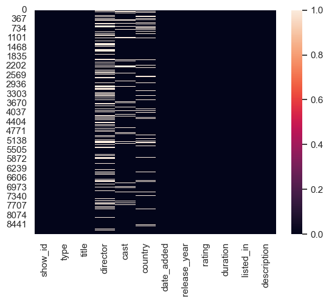

```python
sns.heatmap(netflix.isnull())     # using heatmap to shows the null value count
```

```python
# making copy of dataset changes
netflix_copy = netflix.copy()
netflix_copy.head()
```

|  | show_id | type | title | director | cast | country | date_added | release_year | rating | duration | listed_in | description |
| --- | --- | --- | --- | --- | --- | --- | --- | --- | --- | --- | --- | --- |
| 0 | s1 | Movie | Dick Johnson Is Dead | Kirsten Johnson | NaN | United States | September 25, 2021 | 2020 | PG-13 | 90 min | Documentaries | As her father nears the end of his life, filmm... |
| 1 | s2 | TV Show | Blood & Water | NaN | Ama Qamata, Khosi Ngema, Gail Mabalane, Thaban... | South Africa | September 24, 2021 | 2021 | TV-MA | 2 Seasons | International TV Shows, TV Dramas, TV Mysteries | After crossing paths at a party, a Cape Town t... |
| 2 | s3 | TV Show | Ganglands | Julien Leclercq | Sami Bouajila, Tracy Gotoas, Samuel Jouy, Nabi... | NaN | September 24, 2021 | 2021 | TV-MA | 1 Season | Crime TV Shows, International TV Shows, TV Act... | To protect his family from a powerful drug lor... |
| 3 | s4 | TV Show | Jailbirds New Orleans | NaN | NaN | NaN | September 24, 2021 | 2021 | TV-MA | 1 Season | Docuseries, Reality TV | Feuds, flirtations and toilet talk go down amo... |
| 4 | s5 | TV Show | Kota Factory | NaN | Mayur More, Jitendra Kumar, Ranjan Raj, Alam K... | India | September 24, 2021 | 2021 | TV-MA | 2 Seasons | International TV Shows, Romantic TV Shows, TV ... | In a city of coaching centers known to train I... |

```python
netflix_copy =netflix_copy.dropna(how='any' , subset=['director','cast'])
netflix_copy.head(2)
```

|  | show_id | type | title | director | cast | country | date_added | release_year | rating | duration | listed_in | description |
| --- | --- | --- | --- | --- | --- | --- | --- | --- | --- | --- | --- | --- |
| 2 | s3 | TV Show | Ganglands | Julien Leclercq | Sami Bouajila, Tracy Gotoas, Samuel Jouy, Nabi... | NaN | September 24, 2021 | 2021 | TV-MA | 1 Season | Crime TV Shows, International TV Shows, TV Act... | To protect his family from a powerful drug lor... |
| 5 | s6 | TV Show | Midnight Mass | Mike Flanagan | Kate Siegel, Zach Gilford, Hamish Linklater, H... | NaN | September 24, 2021 | 2021 | TV-MA | 1 Season | TV Dramas, TV Horror, TV Mysteries | The arrival of a charismatic young priest brin... |

```python
netflix_copy.fillna({'country':'missing','rating':'missing','duration':'missing'} , inplace=True)
```

```python
netflix_copy.isnull().sum()
```

```
show_id         0
type            0
title           0
director        0
cast            0
country         0
date_added      0
release_year    0
rating          0
duration        0
listed_in       0
description     0
dtype: int64
```

## 3.3 Preprocessing

- Dealing with duplicate rows
  - Find number of duplicate rows in the dataset.
  - Print the duplicate entries and analyze.
  - Drop the duplicate entries from the dataset.

```python
netflix[netflix.duplicated()]    # to show the duplicate rows
```

|  | show_id | type | title | director | cast | country | date_added | release_year | rating | duration | listed_in | description |
| --- | --- | --- | --- | --- | --- | --- | --- | --- | --- | --- | --- | --- |

```python
netflix.duplicated().sum()       # to show the count of duplicate rows
```

```
0
```

- No duplicate rows are present in this dataset.

```python
# checking size after cleaning
netflix_copy.shape
```

[output not shown]

```python
# save netflix copy into csv
netflix_copy.to_csv('netflix_clean.csv')
```

## 4.EDA Questions

### 4.1. What different types of show or movie are uploaded on Netflix? or

### How many TV shows & Movies are in the dataset? Show with Bar Gragh?

```python
netflix_copy.head(2)
```

|  | show_id | type | title | director | cast | country | date_added | release_year | rating | duration | listed_in | description |
| --- | --- | --- | --- | --- | --- | --- | --- | --- | --- | --- | --- | --- |
| 2 | s3 | TV Show | Ganglands | Julien Leclercq | Sami Bouajila, Tracy Gotoas, Samuel Jouy, Nabi... | missing | September 24, 2021 | 2021 | TV-MA | 1 Season | Crime TV Shows, International TV Shows, TV Act... | To protect his family from a powerful drug lor... |
| 5 | s6 | TV Show | Midnight Mass | Mike Flanagan | Kate Siegel, Zach Gilford, Hamish Linklater, H... | missing | September 24, 2021 | 2021 | TV-MA | 1 Season | TV Dramas, TV Horror, TV Mysteries | The arrival of a charismatic young priest brin... |

```python
# method-1:
netflix_copy.groupby('type')['title'].count().sort_values(ascending = False)
```

```
type
Movie      5522
TV Show     178
Name: title, dtype: int64
```

```python
# method-2:
netflix_copy.type.value_counts().to_frame('Value_count')
```

|  | Value_count |
| --- | --- |
| Movie | 5522 |
| TV Show | 178 |

[output not shown]

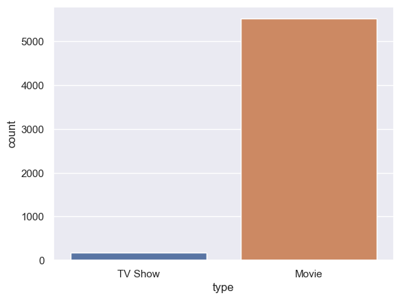

```python
sns.countplot(netflix_copy['type'])     # to show the count of all unique item of a any column in the form of bar gragh
```

#### Obeservation: There are 5522-types of movies and 178-types of tv shows are uploaded on Netflix.

## 4.2 Most watched shows on the Netflix?

```python
netflix_copy.type.value_counts().to_frame('Value_count')
```

|  | Value_count |
| --- | --- |
| Movie | 5522 |
| TV Show | 178 |

```
(array([0, 1]), [Text(0, 0, 'TV Show'), Text(1, 0, 'Movie')])
```

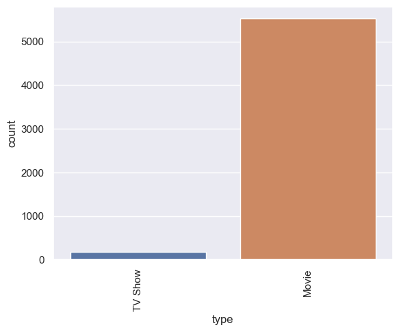

```python
sns.countplot(x=netflix_copy['type'],orient='v')
plt.xticks(rotation=90)
```

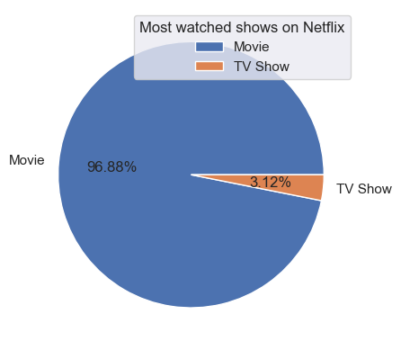

```python
# by using pie chart
type_show = ['Movie','TV Show']
Value_count = [5522,178]
plt.pie(Value_count,labels=type_show,autopct="%2.2f%%")
plt.legend(title= 'Most watched shows on Netflix')
```

### 4.3 Distribution of Ratings? &

### What are the different rating defined by Netflix?

```python
netflix_copy.head(2)
```

|  | show_id | type | title | director | cast | country | date_added | release_year | rating | duration | listed_in | description |
| --- | --- | --- | --- | --- | --- | --- | --- | --- | --- | --- | --- | --- |
| 2 | s3 | TV Show | Ganglands | Julien Leclercq | Sami Bouajila, Tracy Gotoas, Samuel Jouy, Nabi... | missing | September 24, 2021 | 2021 | TV-MA | 1 Season | Crime TV Shows, International TV Shows, TV Act... | To protect his family from a powerful drug lor... |
| 5 | s6 | TV Show | Midnight Mass | Mike Flanagan | Kate Siegel, Zach Gilford, Hamish Linklater, H... | missing | September 24, 2021 | 2021 | TV-MA | 1 Season | TV Dramas, TV Horror, TV Mysteries | The arrival of a charismatic young priest brin... |

[output not shown]

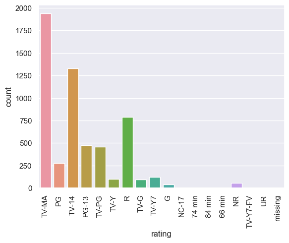

```python
# countplot for distribution

sns.countplot(x=netflix_copy['rating'],orient='v')
plt.xticks(rotation=90)
```

```python
netflix['rating'].nunique()
```

```
17
```

### **Obeservation** :

- Audience prefers mostly TV-MA & TV-14 and less prefers NC-17 as rating.
- There are 17 types of ratings in the netflix.

### 4.4 Which has the highest rating Tv show or Movies?

```python
netflix_copy.head(2)
```

|  | show_id | type | title | director | cast | country | date_added | release_year | rating | duration | listed_in | description |
| --- | --- | --- | --- | --- | --- | --- | --- | --- | --- | --- | --- | --- |
| 2 | s3 | TV Show | Ganglands | Julien Leclercq | Sami Bouajila, Tracy Gotoas, Samuel Jouy, Nabi... | missing | September 24, 2021 | 2021 | TV-MA | 1 Season | Crime TV Shows, International TV Shows, TV Act... | To protect his family from a powerful drug lor... |
| 5 | s6 | TV Show | Midnight Mass | Mike Flanagan | Kate Siegel, Zach Gilford, Hamish Linklater, H... | missing | September 24, 2021 | 2021 | TV-MA | 1 Season | TV Dramas, TV Horror, TV Mysteries | The arrival of a charismatic young priest brin... |

```python
netflix.groupby("type")["rating"].agg(pd.Series.mode)
```

```
type
Movie      TV-MA
TV Show    TV-MA
Name: rating, dtype: object
```

#### Adding new feature

- new_genre (Genre 1,Genre 2,Genre 3)

```python
new_genre = netflix_copy['listed_in'].str.split(" ",2)
new_genre
```

```
2       [Crime, TV, Shows, International TV Shows, TV ...
5                  [TV, Dramas,, TV Horror, TV Mysteries]
6                            [Children, &, Family Movies]
7       [Dramas,, Independent, Movies, International M...
8                        [British, TV, Shows, Reality TV]
                              ...
8801          [Dramas,, International, Movies, Thrillers]
8802                   [Cult, Movies,, Dramas, Thrillers]
8804                          [Comedies,, Horror, Movies]
8805               [Children, &, Family Movies, Comedies]
8806    [Dramas,, International, Movies, Music & Music...
Name: listed_in, Length: 5700, dtype: object
```

```python
netflix_copy['Genre 1'] = new_genre.str.get(0)
netflix_copy['Genre 2'] = new_genre.str.get(1)
netflix_copy['Genre 3'] = new_genre.str.get(2)
netflix_copy.head(2)
```

|  | show_id | type | title | director | cast | country | date_added | release_year | rating | duration | listed_in | description | Genre 1 | Genre 2 | Genre 3 |
| --- | --- | --- | --- | --- | --- | --- | --- | --- | --- | --- | --- | --- | --- | --- | --- |
| 2 | s3 | TV Show | Ganglands | Julien Leclercq | Sami Bouajila, Tracy Gotoas, Samuel Jouy, Nabi... | missing | September 24, 2021 | 2021 | TV-MA | 1 Season | Crime TV Shows, International TV Shows, TV Act... | To protect his family from a powerful drug lor... | Crime | TV | Shows, International TV Shows, TV Action & Adv... |
| 5 | s6 | TV Show | Midnight Mass | Mike Flanagan | Kate Siegel, Zach Gilford, Hamish Linklater, H... | missing | September 24, 2021 | 2021 | TV-MA | 1 Season | TV Dramas, TV Horror, TV Mysteries | The arrival of a charismatic young priest brin... | TV | Dramas, | TV Horror, TV Mysteries |

```python
netflix_copy['Genre 1'].describe(include=all)
```

```
count        5700
unique         28
top       Dramas,
freq         1450
Name: Genre 1, dtype: object
```

```python
netflix_copy['Genre 2'].describe(include=all)
```

```
count     5198
unique      31
top          &
freq      1429
Name: Genre 2, dtype: object
```

```python
netflix_copy['Genre 3'].describe(include=all)
```

```
count       4698
unique       225
top       Movies
freq         960
Name: Genre 3, dtype: object
```

```python
netflix_copy.drop('listed_in',axis=1,inplace=True)
netflix_copy.head(2)
```

|  | show_id | type | title | director | cast | country | date_added | release_year | rating | duration | description | Genre 1 | Genre 2 | Genre 3 |
| --- | --- | --- | --- | --- | --- | --- | --- | --- | --- | --- | --- | --- | --- | --- |
| 2 | s3 | TV Show | Ganglands | Julien Leclercq | Sami Bouajila, Tracy Gotoas, Samuel Jouy, Nabi... | missing | September 24, 2021 | 2021 | TV-MA | 1 Season | To protect his family from a powerful drug lor... | Crime | TV | Shows, International TV Shows, TV Action & Adv... |
| 5 | s6 | TV Show | Midnight Mass | Mike Flanagan | Kate Siegel, Zach Gilford, Hamish Linklater, H... | missing | September 24, 2021 | 2021 | TV-MA | 1 Season | The arrival of a charismatic young priest brin... | TV | Dramas, | TV Horror, TV Mysteries |

```python
netflix_copy.duplicated().sum()
```

```
0
```

```python
netflix_copy.groupby(['Genre 1'])['release_year'].count().sort_values(ascending = False)
```

```
Genre 1
Dramas,           1450
Comedies,         1083
Action             848
Children           548
Stand-Up           317
Horror             274
Documentaries,     234
International      181
Documentaries      163
Dramas             136
Comedies           101
Classic             75
Thrillers           65
Crime               37
Anime               30
Movies              30
British             21
Independent         20
Music               18
TV                  17
Sci-Fi              13
Cult                12
Kids'               11
Docuseries           7
Romantic             4
Docuseries,          3
LGBTQ                1
Reality              1
Name: release_year, dtype: int64
```

```python
netflix_copy.groupby(['Genre 2'])['release_year'].count().sort_values(ascending = False)
```

```
Genre 2
&                 1429
International     1297
Independent        507
Movies,            444
Dramas,            418
Comedy             317
Romantic           142
TV                 124
Thrillers           82
Music               80
Sports              61
Movies              61
Faith               46
Horror              37
Cult                30
Dramas              29
LGBTQ               24
Features,           18
Sci-Fi              14
Series,             11
Shows                9
TV,                  6
Comedies             2
Action               2
Stand-Up             2
Horror,              1
Features             1
Science              1
Documentaries,       1
Documentaries        1
Comedies,            1
Name: release_year, dtype: int64
```

```python
netflix_copy.groupby(['Genre 3'])['release_year'].count().sort_values(ascending = False)
```

```
Genre 3
Movies                                              960
Movies, Romantic Movies                             356
International Movies                                332
Movies, International Movies                        289
Family Movies, Comedies                             193
                                                   ...
Adventure, Children & Family Movies, Cult Movies      1
Music & Musicals, Sci-Fi & Fantasy                    1
Dramas, LGBTQ Movies                                  1
& Nature TV, TV Dramas                                1
Adventure, Classic Movies, Sci-Fi & Fantasy           1
Name: release_year, Length: 225, dtype: int64
```

### 4.5 Finding the best Month for releasing content?

```python
netflix_copy.dtypes
```

```
show_id         object
type            object
title           object
director        object
cast            object
country         object
date_added      object
release_year     int64
rating          object
duration        object
description     object
Genre 1         object
Genre 2         object
Genre 3         object
dtype: object
```

```python
netflix_copy["date_added"]=pd.to_datetime(netflix_copy['date_added'])
netflix_copy.head(2)
```

|  | show_id | type | title | director | cast | country | date_added | release_year | rating | duration | description | Genre 1 | Genre 2 | Genre 3 |
| --- | --- | --- | --- | --- | --- | --- | --- | --- | --- | --- | --- | --- | --- | --- |
| 2 | s3 | TV Show | Ganglands | Julien Leclercq | Sami Bouajila, Tracy Gotoas, Samuel Jouy, Nabi... | missing | 2021-09-24 | 2021 | TV-MA | 1 Season | To protect his family from a powerful drug lor... | Crime | TV | Shows, International TV Shows, TV Action & Adv... |
| 5 | s6 | TV Show | Midnight Mass | Mike Flanagan | Kate Siegel, Zach Gilford, Hamish Linklater, H... | missing | 2021-09-24 | 2021 | TV-MA | 1 Season | The arrival of a charismatic young priest brin... | TV | Dramas, | TV Horror, TV Mysteries |

```python
netflix_copy['year_added'] = netflix_copy["date_added"].dt.year
netflix_copy['month_added'] = netflix_copy["date_added"].dt.month
netflix_copy.head(2)
```

|  | show_id | type | title | director | cast | country | date_added | release_year | rating | duration | description | Genre 1 | Genre 2 | Genre 3 | year_added | month_added |
| --- | --- | --- | --- | --- | --- | --- | --- | --- | --- | --- | --- | --- | --- | --- | --- | --- |
| 2 | s3 | TV Show | Ganglands | Julien Leclercq | Sami Bouajila, Tracy Gotoas, Samuel Jouy, Nabi... | missing | 2021-09-24 | 2021 | TV-MA | 1 Season | To protect his family from a powerful drug lor... | Crime | TV | Shows, International TV Shows, TV Action & Adv... | 2021 | 9 |
| 5 | s6 | TV Show | Midnight Mass | Mike Flanagan | Kate Siegel, Zach Gilford, Hamish Linklater, H... | missing | 2021-09-24 | 2021 | TV-MA | 1 Season | The arrival of a charismatic young priest brin... | TV | Dramas, | TV Horror, TV Mysteries | 2021 | 9 |

```python
netflix_copy.head(2)
```

|  | show_id | type | title | director | cast | country | date_added | release_year | rating | duration | description | Genre 1 | Genre 2 | Genre 3 | year_added | month_added |
| --- | --- | --- | --- | --- | --- | --- | --- | --- | --- | --- | --- | --- | --- | --- | --- | --- |
| 2 | s3 | TV Show | Ganglands | Julien Leclercq | Sami Bouajila, Tracy Gotoas, Samuel Jouy, Nabi... | missing | 2021-09-24 | 2021 | TV-MA | 1 Season | To protect his family from a powerful drug lor... | Crime | TV | Shows, International TV Shows, TV Action & Adv... | 2021 | 9 |
| 5 | s6 | TV Show | Midnight Mass | Mike Flanagan | Kate Siegel, Zach Gilford, Hamish Linklater, H... | missing | 2021-09-24 | 2021 | TV-MA | 1 Season | The arrival of a charismatic young priest brin... | TV | Dramas, | TV Horror, TV Mysteries | 2021 | 9 |

```python
# converting month number to month name
netflix_copy['month_final'] = netflix_copy['month_added'].replace({1:'Jan', 2:'Feb', 3:'Mar', 4:'Apr', 5:'May', 6:'June', 7:'July', 8:'Aug', 9:'Sep', 10:'Oct', 11:'Nov', 12:'Dec'})
netflix_copy.head(2)
```

|  | show_id | type | title | director | cast | country | date_added | release_year | rating | duration | description | Genre 1 | Genre 2 | Genre 3 | year_added | month_added | month_final |
| --- | --- | --- | --- | --- | --- | --- | --- | --- | --- | --- | --- | --- | --- | --- | --- | --- | --- |
| 2 | s3 | TV Show | Ganglands | Julien Leclercq | Sami Bouajila, Tracy Gotoas, Samuel Jouy, Nabi... | missing | 2021-09-24 | 2021 | TV-MA | 1 Season | To protect his family from a powerful drug lor... | Crime | TV | Shows, International TV Shows, TV Action & Adv... | 2021 | 9 | Sep |
| 5 | s6 | TV Show | Midnight Mass | Mike Flanagan | Kate Siegel, Zach Gilford, Hamish Linklater, H... | missing | 2021-09-24 | 2021 | TV-MA | 1 Season | The arrival of a charismatic young priest brin... | TV | Dramas, | TV Horror, TV Mysteries | 2021 | 9 | Sep |

```python
netflix_copy.month_final.value_counts().to_frame('Value_count')
```

|  | Value_count |
| --- | --- |
| July | 535 |
| Dec | 511 |
| Oct | 507 |
| Jan | 503 |
| Apr | 501 |
| Mar | 497 |
| Aug | 492 |
| Sep | 475 |
| Nov | 468 |
| June | 457 |
| May | 405 |
| Feb | 349 |

[output not shown]

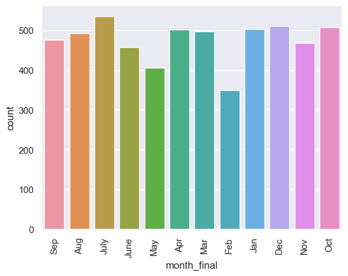

```python
sns.countplot(x=netflix_copy['month_final'],orient='v')
plt.xticks(rotation=90)
```

**Obeservation** : Its clearly shows that july month has maximum number of movies released.july is the best Month for releasing content.

### 4.6 movies made on year basis? or

### In which year highest number of the TV shows & Movies were released? show with Bar Graph

```python
netflix_copy.head(2)
```

|  | show_id | type | title | director | cast | country | date_added | release_year | rating | duration | description | Genre 1 | Genre 2 | Genre 3 | year_added | month_added | month_final |
| --- | --- | --- | --- | --- | --- | --- | --- | --- | --- | --- | --- | --- | --- | --- | --- | --- | --- |
| 2 | s3 | TV Show | Ganglands | Julien Leclercq | Sami Bouajila, Tracy Gotoas, Samuel Jouy, Nabi... | missing | 2021-09-24 | 2021 | TV-MA | 1 Season | To protect his family from a powerful drug lor... | Crime | TV | Shows, International TV Shows, TV Action & Adv... | 2021 | 9 | Sep |
| 5 | s6 | TV Show | Midnight Mass | Mike Flanagan | Kate Siegel, Zach Gilford, Hamish Linklater, H... | missing | 2021-09-24 | 2021 | TV-MA | 1 Season | The arrival of a charismatic young priest brin... | TV | Dramas, | TV Horror, TV Mysteries | 2021 | 9 | Sep |

```python
netflix_copy.year_added.value_counts().to_frame('Value_count')
```

|  | Value_count |
| --- | --- |
| 2019 | 1323 |
| 2020 | 1248 |
| 2018 | 1125 |
| 2021 | 962 |
| 2017 | 744 |
| 2016 | 206 |
| 2015 | 51 |
| 2014 | 14 |
| 2011 | 13 |
| 2013 | 7 |
| 2012 | 3 |
| 2009 | 2 |
| 2008 | 1 |
| 2010 | 1 |

```python
netflix_copy.dtypes
```

```
show_id                 object
type                    object
title                   object
director                object
cast                    object
country                 object
date_added      datetime64[ns]
release_year             int64
rating                  object
duration                object
description             object
Genre 1                 object
Genre 2                 object
Genre 3                 object
year_added               int64
month_added              int64
month_final             object
dtype: object
```

```python
netflix_copy["date_added"].dt.year.value_counts()
```

```
2019    1323
2020    1248
2018    1125
2021     962
2017     744
2016     206
2015      51
2014      14
2011      13
2013       7
2012       3
2009       2
2008       1
2010       1
Name: date_added, dtype: int64
```

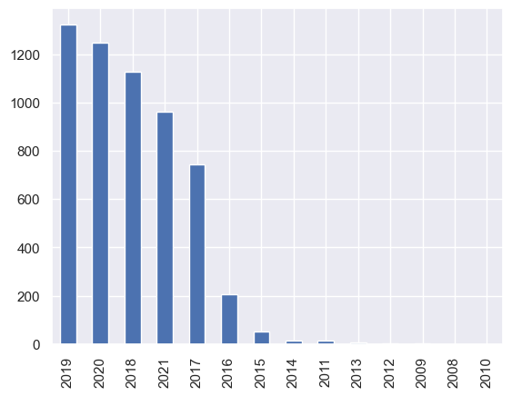

```python
netflix_copy["date_added"].dt.year.value_counts().plot(kind='bar')
```

### 4.7 Show only the title of all TV shows that were released in India only.

```python
netflix_copy.head(2)
```

|  | show_id | type | title | director | cast | country | date_added | release_year | rating | duration | description | Genre 1 | Genre 2 | Genre 3 | year_added | month_added | month_final |
| --- | --- | --- | --- | --- | --- | --- | --- | --- | --- | --- | --- | --- | --- | --- | --- | --- | --- |
| 2 | s3 | TV Show | Ganglands | Julien Leclercq | Sami Bouajila, Tracy Gotoas, Samuel Jouy, Nabi... | missing | 2021-09-24 | 2021 | TV-MA | 1 Season | To protect his family from a powerful drug lor... | Crime | TV | Shows, International TV Shows, TV Action & Adv... | 2021 | 9 | Sep |
| 5 | s6 | TV Show | Midnight Mass | Mike Flanagan | Kate Siegel, Zach Gilford, Hamish Linklater, H... | missing | 2021-09-24 | 2021 | TV-MA | 1 Season | The arrival of a charismatic young priest brin... | TV | Dramas, | TV Horror, TV Mysteries | 2021 | 9 | Sep |

```python
netflix[(netflix['type'] == 'TV Show') & (netflix['country'] == 'India')]["title"]
```

```
4                             Kota Factory
39                            Chhota Bheem
50                           Dharmakshetra
66           Raja Rasoi Aur Anya Kahaniyan
69          Stories by Rabindranath Tagore
                       ...
8173                             Thackeray
8235                           The Calling
8321    The Golden Years with Javed Akhtar
8349                The House That Made Me
8775                       Yeh Meri Family
Name: title, Length: 79, dtype: object
```

```python
netflix[(netflix['type'] == 'TV Show') & (netflix['country'] == 'India')]["title"].shape
```

```
(79,)
```

**Obeservation**:There are 79 tv shows that were released in India only.

### 4.8 Show top 10 director, who gave the highest number of TV shows & Movies to Netflix?

```python
netflix.head(2)
```

|  | show_id | type | title | director | cast | country | date_added | release_year | rating | duration | listed_in | description |
| --- | --- | --- | --- | --- | --- | --- | --- | --- | --- | --- | --- | --- |
| 0 | s1 | Movie | Dick Johnson Is Dead | Kirsten Johnson | NaN | United States | September 25, 2021 | 2020 | PG-13 | 90 min | Documentaries | As her father nears the end of his life, filmm... |
| 1 | s2 | TV Show | Blood & Water | NaN | Ama Qamata, Khosi Ngema, Gail Mabalane, Thaban... | South Africa | September 24, 2021 | 2021 | TV-MA | 2 Seasons | International TV Shows, TV Dramas, TV Mysteries | After crossing paths at a party, a Cape Town t... |

```python
netflix["director"].value_counts().head(10)
```

```
Rajiv Chilaka             19
Raúl Campos, Jan Suter    18
Marcus Raboy              16
Suhas Kadav               16
Jay Karas                 14
Cathy Garcia-Molina       13
Martin Scorsese           12
Youssef Chahine           12
Jay Chapman               12
Steven Spielberg          11
Name: director, dtype: int64
```

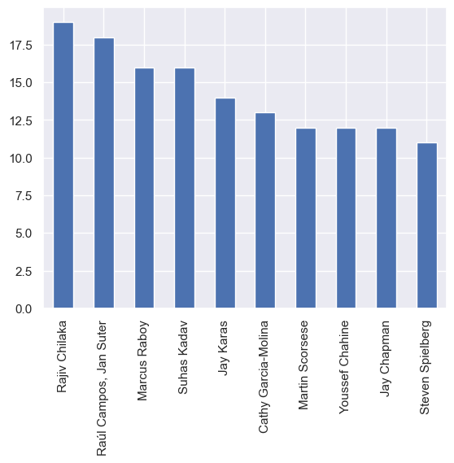

```python
netflix["director"].value_counts().head(10).plot(kind='bar')
```

# 5.Conclusions

**This analysis provides insights into content trends and viewer preferences on Netflix, serving as a foundation for future decision-making in content creation and distribution.**